# Experiment 2 - Rosenbaum, Grassie & Hartley

Gail Rosenbaum

01/15/2022

# Setup

## Load Libraries

Note: Experiment 2 data were originally published in the following paper: Rouhani, N., Norman, K. A., & Niv, Y. (2018). Dissociable effects of surprising rewards on learning and memory. Journal of Experimental Psychology: Learning, Memory, and Cognition, 44(9), 1430–1443. https://doi.org/10.1037/xlm0000518

# Assess model fit

In the full dataset, the correlation between the model’s value estimates and actual value estimates from participants’ task experience: mean = 0.42 SD = 0.34

# Compute asymmetry index

Asymmetry index: Mean = -0.08 SD = 0.37

# Identify participants with good vs. subpar model fit

Number of participants total (regardless of fit) = 383

Number of participants with correlation lower that 0 or negative loglikelihood less than 0 (i.e., poorly fit by the model) = 78

Number of participants with adequate model fit = 305

# Analyses with participants with good model fit (main text analysis)

In the subset of data with good RL model fit, the correlation between the model’s value estimates and actual value estimates from participants’ task experience: mean = 0.54 SD = 0.22

## Clean up “good fit” dataset

## Plot parameter distributions

Appendix 1—figure 14A-C

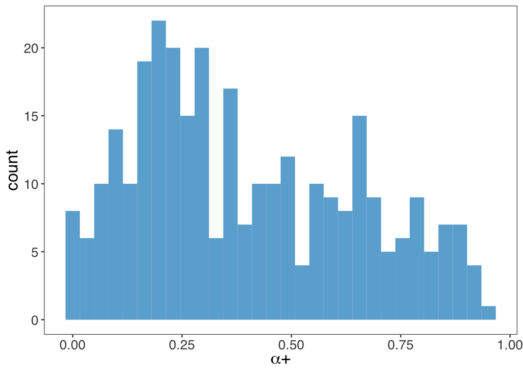

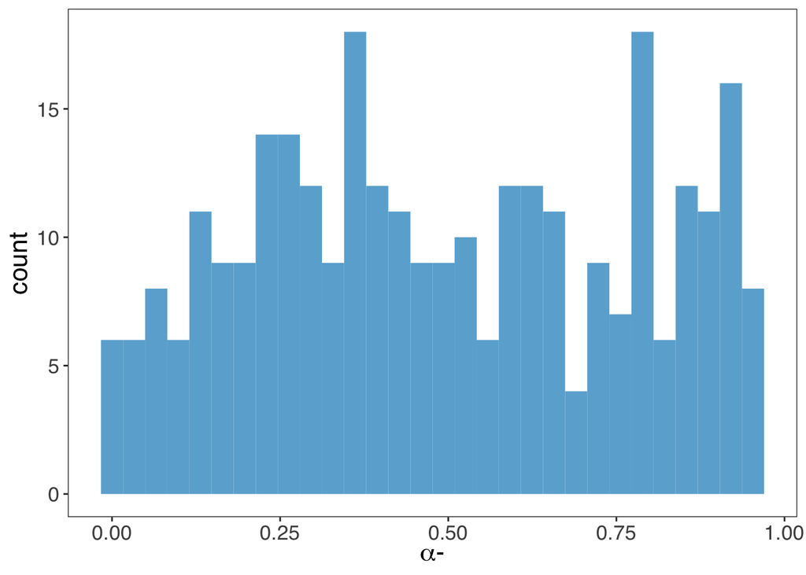

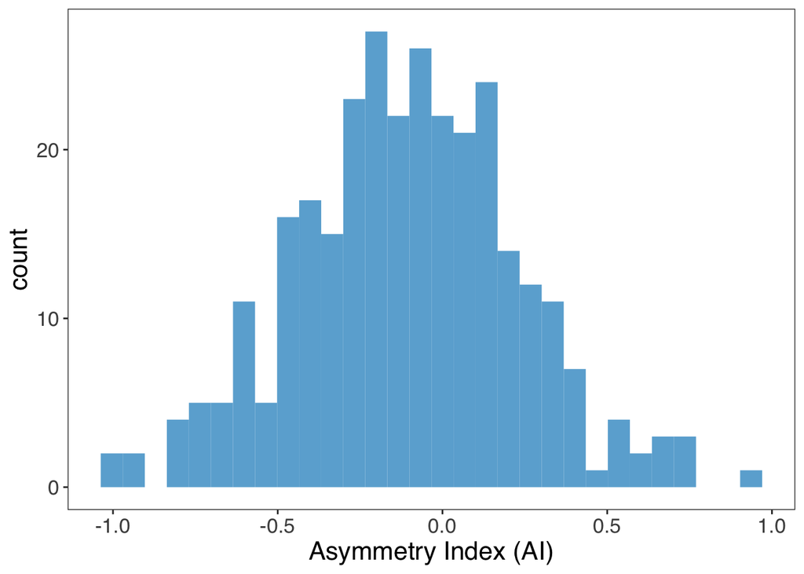

Asymmetry index in subjects with good RL model fit: Mean = -0.11 SD = 0.34

## Memory Mixed-Effects Regression

### Model

|  | hit |  |  |  |
| --- | --- | --- | --- | --- |
| Predictors | z | p | Odds Ratios | CI |
| (Intercept) | 21.41 | **<0.001** | 3.49 | 3.12 – 3.92 |
| AIScale | -1.05 | 0.295 | 0.94 | 0.84 – 1.05 |
| AbsRPEScale | 5.09 | **<0.001** | 1.19 | 1.12 – 1.28 |
| PositiveRPEC | -1.87 | 0.062 | 0.94 | 0.89 – 1.00 |
| TrialScale | -8.92 | **<0.001** | 0.77 | 0.72 – 0.81 |
| FAScale | 0.67 | 0.506 | 1.04 | 0.93 – 1.16 |
| AIScale * AbsRPEScale | -1.81 | 0.070 | 0.95 | 0.89 – 1.00 |
| AIScale * PositiveRPEC | 2.44 | **0.015** | 1.08 | 1.02 – 1.15 |
| AbsRPEScale * PositiveRPEC | -0.51 | 0.610 | 0.98 | 0.92 – 1.05 |
| (AIScale * AbsRPEScale) * PositiveRPEC | 2.19 | **0.029** | 1.07 | 1.01 – 1.13 |
| Random Effects |  |  |  |  |
| σ<sup>2</sup> | 3.29 |  |  |  |
| τ<sub>00</sub> <sub>subj</sub> | 0.69 |  |  |  |
| τ<sub>11</sub> <sub>subj.AbsRPEScale</sub> | 0.01 |  |  |  |
| τ<sub>11</sub> <sub>subj.PositiveRPEC</sub> | 0.01 |  |  |  |
| τ<sub>11</sub> <sub>subj.TrialScale</sub> | 0.00 |  |  |  |
| ρ<sub>01</sub> |  |  |  |  |
| ρ<sub>01</sub> |  |  |  |  |
| ICC | 0.17 |  |  |  |
| N <sub>subj</sub> | 305 |  |  |  |
| Observations | 7517 |  |  |  |
| Marginal R<sup>2</sup> / Conditional R<sup>2</sup> | 0.027 / 0.195 |  |  |  |

### Plot

Figure 6A

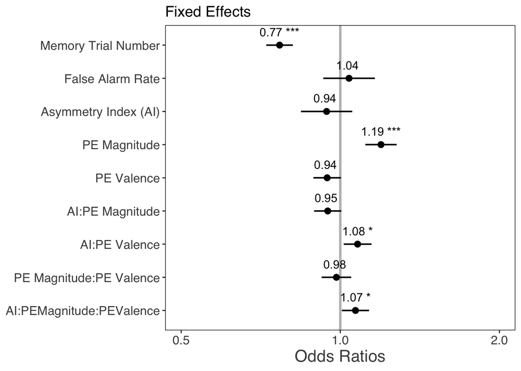

Figure 6B

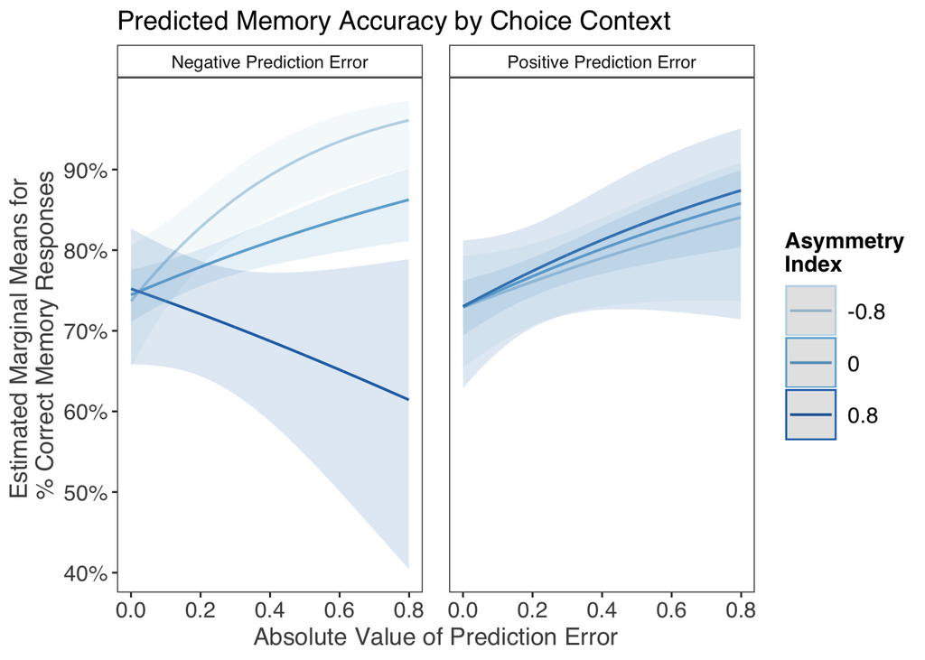

Appendix 1—-figure 13D

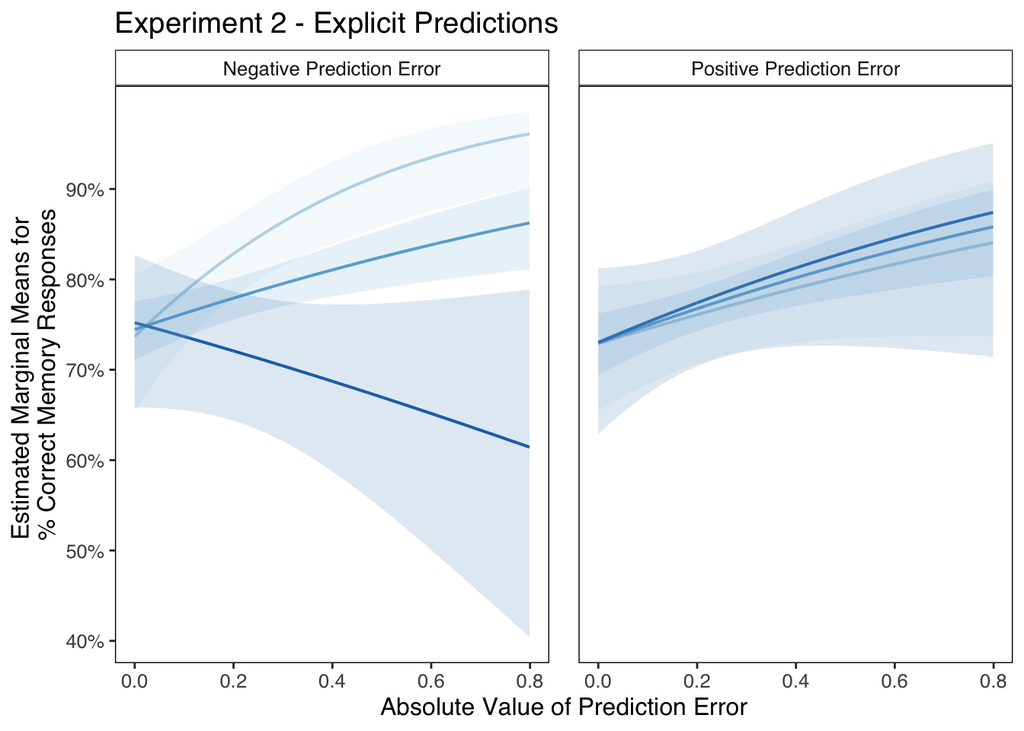

# Sensitivity analysis (Appendix 1)

Rerunning the mixed-effects model with the full dataset, including those with poor model fit.

## Model

|  | hit |  |  |  |
| --- | --- | --- | --- | --- |
| Predictors | z | p | Odds Ratios | CI |
| (Intercept) | 21.47 | **<0.001** | 3.28 | 2.94 – 3.66 |
| AIScale | -1.17 | 0.241 | 0.94 | 0.85 – 1.04 |
| AbsRPEScale | 5.30 | **<0.001** | 1.18 | 1.11 – 1.26 |
| PositiveRPEC | -1.94 | 0.052 | 0.95 | 0.90 – 1.00 |
| TrialScale | -10.99 | **<0.001** | 0.74 | 0.70 – 0.78 |
| FAScale | 0.00 | 0.997 | 1.00 | 0.90 – 1.11 |
| AIScale * AbsRPEScale | -1.33 | 0.183 | 0.96 | 0.91 – 1.02 |
| AIScale * PositiveRPEC | 2.83 | **0.005** | 1.08 | 1.02 – 1.14 |
| AbsRPEScale * PositiveRPEC | -0.72 | 0.474 | 0.98 | 0.92 – 1.04 |
| (AIScale * AbsRPEScale) * PositiveRPEC | 1.80 | 0.072 | 1.05 | 1.00 – 1.11 |
| Random Effects |  |  |  |  |
| σ<sup>2</sup> | 3.29 |  |  |  |
| τ<sub>00</sub> <sub>subj</sub> | 0.81 |  |  |  |
| τ<sub>11</sub> <sub>subj.AbsRPEScale</sub> | 0.02 |  |  |  |
| τ<sub>11</sub> <sub>subj.TrialScale</sub> | 0.01 |  |  |  |
| ρ<sub>01</sub> |  |  |  |  |
| ρ<sub>01</sub> |  |  |  |  |
| ICC | 0.20 |  |  |  |
| N <sub>subj</sub> | 383 |  |  |  |
| Observations | 9147 |  |  |  |
| Marginal R<sup>2</sup> / Conditional R<sup>2</sup> | 0.030 / 0.222 |  |  |  |

## Plot

Appendix 1—figure 15A

[figure not shown]

Appendix 1—figure 15B

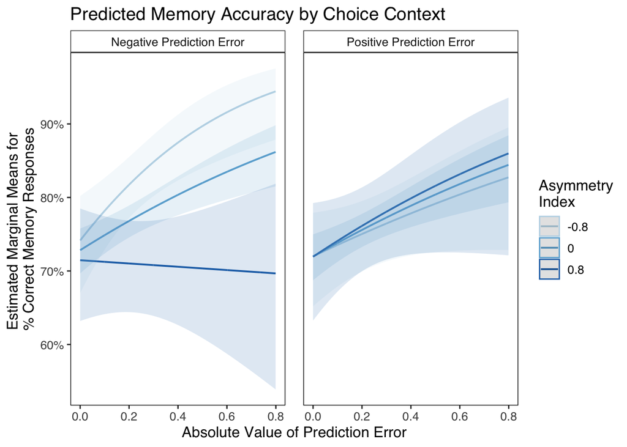

Appendix 1—figure 15C

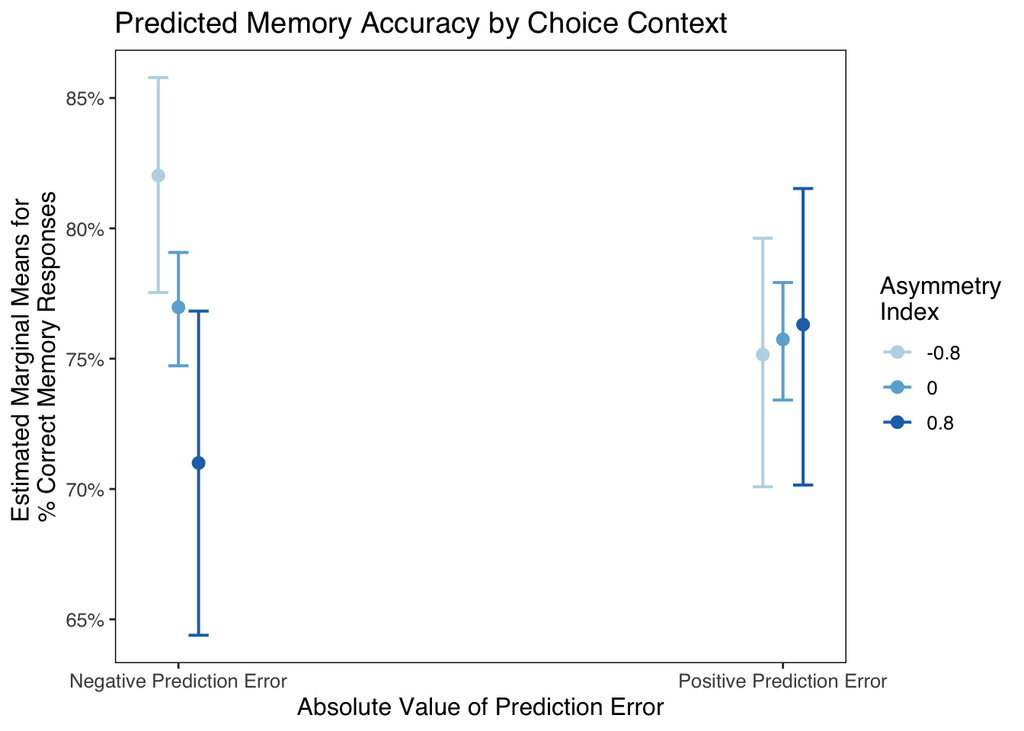